# A drought graph

Kate Newton

16 June 2020

This script creates the drought visualisation used in the [RNZ story](https://www.rnz.co.nz/stories/2018750899/climate-extremes) about projected changes to climate extremes in New Zealand.

```r
library(tidyverse)
library(readxl)
library(ggplot2)
library(lubridate)
library(viridis)
library(scales)
```

## Import drought data

The data used to create this graph comes from [NIWA’s Drought Monitor](https://niwa.co.nz/climate/information-and-resources/drought-monitor). Unfortunately there is no way to download the files for each district in bulk; files must be saved individually by selecting from a dropdown and then exporting the .csv. The resulting files can be found in the /drought-indices folder in this repo, but the files are only current to mid-May 2020 and would need to be re-downloaded to create an up-to-date version of the graph.

```r
mydir = "drought-indices"
myfiles = list.files(path=mydir, pattern="*.csv", full.names=TRUE) # create list of files

#import in bulk, creating an additional variable based on the filename to identify the different districts (fortunately the files have a very regular naming convention)

drought_data <- do.call("rbind", lapply(myfiles, function(x) {
  dat <- read.csv(x, header=TRUE)
  dat$district <- tools::file_path_sans_ext(basename(x))
  dat
}))
```

## Tidying data

The next part of the script prepares the data for plotting, by identifying consecutive drought days, calculating the length of each drought period, and creating some additional date variables to filter and plot with.

```r
drought_data <- drought_data %>%
  rename(date=OBS_DATE,
         value=VAL) %>%
  mutate(date=ymd(date)) %>%
  filter(NZDI_INDICATOR=="NZDI") #keep just the drought index indicator (this is a composite value created from the four other indicators)

drought_days <- drought_data %>%
  filter(value>1.49) #NIWA defines a district as in drought if its index value is >=1.5

drought_days$consec <- cumsum(!c(TRUE, diff(drought_days$date) == 1)) # create a variable that assigns the same value to each consecutive drought day. When the difference between dates is more than one day, it assigns the next value, and so on. This allows the data to then be grouped by drought period.

drought_count_index <- drought_days %>%
  group_by(district, consec) %>%
  summarise(total=n(), start_date = min(date), end_date = max(date)) %>%  # count the length of each drought period
  mutate(start_month = month(start_date, label = T),
         start_year = year(start_date),
         start_day = day(start_date),
         end_month = month(end_date, label = T),
         end_year = year(end_date),
         end_day = day(end_date))
```

When I initially analysed this data I attempted to visualise all years in the drought index, by messing around with faceting and other functions. However, because there are 67 districts, and many of the drought periods overlap, the visualisations (variations on bar and Gantt plots) ended up being unwieldy and difficult to read. 2020 is the period of interest for my story, so I’ve subsetted that data here so I can plot a single year of data.

```r
twentytwenty <- drought_count_index %>%
  filter(start_year=="2019"& start_month %in% c("Nov", "Dec")|start_year=="2020") #Nov/Dec 2019 included as a quick scan of previous years shows many summer droughts that start before the beginning of the calendar year. As it happens, none of the 2020 drought periods began in 2019 but this addition to the code could be used for other years when droughts did begin before 1 January.

twentytwenty <- twentytwenty %>%
  group_by(district) %>%
  mutate(total_days = sum(total)) %>% #create a variable of the total days a district has spent in drought (over one or more drought periods)
  ungroup

twentytwenty <- twentytwenty %>%
  mutate(district=str_remove_all(district, "_District")) %>% #a bit of housekeeping so the labels are nice
  mutate(district=str_replace_all(district, "_", " "))
```

## Visualise the 2020 data

There are other ways to make this plot, but using the quickplot qplot() function works perfectly well for what I want to do here. In my published version, I used the extrafont pkg to load Verdana as a font, but I’ve included the basic version here.

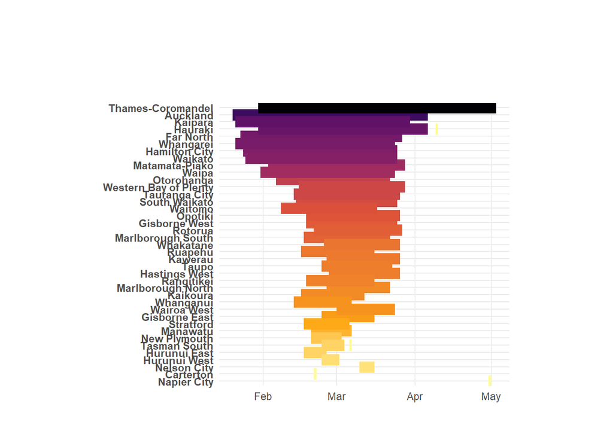

```r
qplot(ymin = start_date,
      ymax = end_date,
      x = reorder(district, total_days), #order so the district that's spent longest in drought is at the top
      label = district,
      size = 0.4,
      colour = total,
      geom = "linerange",
      data = twentytwenty) +
  coord_flip() +
  theme(legend.position = "none") +
  scale_color_viridis_c(option = "inferno", direction = -1) +
  theme_minimal() +
  theme(axis.title = element_blank(),
        axis.text.y = element_text(face = "bold"),
        legend.position = 'none',
        axis.ticks = element_blank(),
        panel.grid.minor = element_blank(),
        plot.margin = unit(c(3,3,1,3), "cm"))
```

```r
# ggsave("images/drought-periods.tiff", dpi = 300, height = 19.2, width = 33.6, units = "cm")
```